# HW 4 Solutions

## Question 1

### (a) (3 pts)

Substituting in the observed data,

$L(\lambda) = \left( \dfrac{\lambda^2 e^{-\lambda}}{2!} \right) \cdot \left( \dfrac{\lambda^4 e^{-\lambda}}{4!} \right) \cdot \left( \dfrac{\lambda^6 e^{-\lambda}}{6!} \right) \cdot \left( \dfrac{\lambda^6 e^{-\lambda}}{6!} \right) \cdot \left( \dfrac{\lambda^3 e^{-\lambda}}{3!} \right) \cdot \left( \dfrac{\lambda^1 e^{-\lambda}}{1!} \right)$

this simplifies to

$L(\lambda) = \dfrac{\lambda^{22} e^{-6 \lambda}}{2! \cdot 4! \cdot 6! \cdot 6! \cdot 3! \cdot 1!}$

**Grading:** 1 pt for using the correct probability function (the Poisson probability function), 1 pt for applying the probability function to each observation, 1 pt for multiplying all the probabilities together.

### (b) (2 pts)

The log likelihood is

$\log L(\lambda) = \log \left( \dfrac{\lambda^{22} e^{-6 \lambda}}{2! \cdot 4! \cdot 6! \cdot 6! \cdot 3! \cdot 1!} \right) = 22 \log(\lambda) - 6 \lambda - \log(2! \cdot 4! \cdot 6! \cdot 6! \cdot 3! \cdot 1!)$

**Grading:** Lose 1 pt for errors applying rules of logarithms

### (c) (3 pts)

Differentiating,

$\frac{d}{d \lambda} \log L(\lambda) = \dfrac{22}{\lambda} - 6$

We then set the derivative equal to 0, and solve for $\lambda$:

$\widehat{\lambda} = \dfrac{22}{6} = 3.67$.

**Grading:** 1 pt for the derivative, 1 pt for setting to 0, 1 pt for correctly solving for $\lambda$

## Question 2

### (a) (3 pts)

We know that

$\ell(\lambda) = \sum \limits_{i=1}^n \log(P(Y = Y_i))$

Applying the distribution for this problem,

$\ell(\lambda) = \sum \limits_{i=1}^n \log \left( \dfrac{\lambda^{Y_i} e^{-\lambda}}{Y_i!} \right)$

This can be simplified by splitting up the log and the sum:

$$\begin{align*}
\ell(\lambda) &= \sum \limits_{i=1}^n (Y_i \log(\lambda) - \lambda -
\log(Y_i!)) \\
&= \log(\lambda) \sum \limits_{i=1}^n Y_i - n \lambda - \sum
\limits_{i=1}^n \log(Y_i!)
\end{align*}$$

**Grading:** 1 pt for using the correct probability function (the Poisson probability function), 1 pt for applying the probability function to each observation $Y_i$, 1 pt for simplifying the log likelihood.

### (b) (4 pts)

Differentiating,

$\frac{d}{d \lambda} \log L(\lambda) = \frac{\sum \limits_{i=1}^n Y_i}{\lambda} - n \ \ \overset{set}{=} \ \ 0$

We then solve for $\lambda$:

$\widehat{\lambda} = \frac{\sum \limits_{i=1}^n Y_i}{n}$

**Grading:** 2 pts for correctly taking the derivative, 1 pt for setting to 0, 1 pt for correctly solving for $\lambda$

## Question 3

### (a) (3 pts)

The explanatory variables of interest are Posts, Views, Authors, and Forum; we want all of these variables in the model. The variable of interest is whether there is at least one deleted post in the thread. This is a *new* variable we will need to create using the DeletedPosts variable:

```r
sfn <- sfn %>%
  mutate(hasDeleted = DeletedPosts > 0)
```

**Grading:** 1 pt for explanatory variable, 1 pt for response variable, 1 pt for creating the new variable for the response (if they create it below in a different question, they can still get the points here).

### (b) (6 pts)

Here are empirical logit plots for Posts, Views, and Authors:

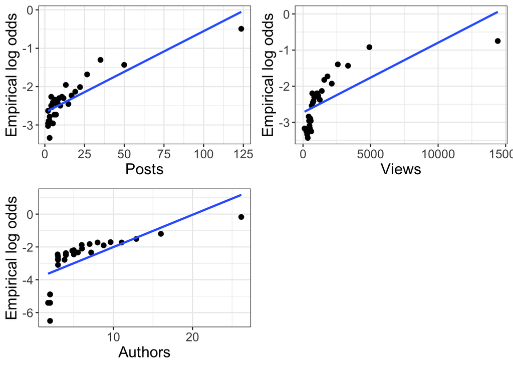

```r
p1 <- logodds_plot(sfn, 30, "equal_size", "Posts", "hasDeleted", reg_formula = y ~ x)
p2 <- logodds_plot(sfn, 30, "equal_size", "Views", "hasDeleted", reg_formula = y ~ x)
p3 <- logodds_plot(sfn, 30, "equal_size", "Authors", "hasDeleted", reg_formula = y ~ x)

grid.arrange(p1, p2, p3, ncol=2)
```

All three variables show potentially non-linear relationships, so transformations may be needed. Here are some log transformations:

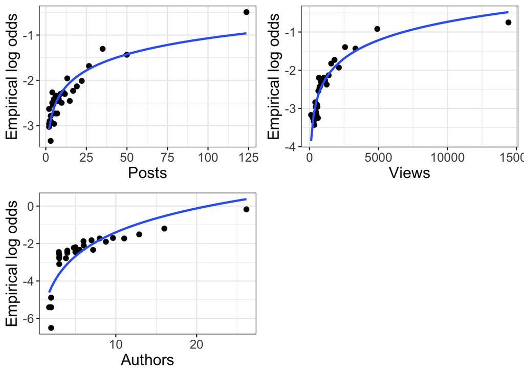

```r
p1 <- logodds_plot(sfn, 30, "equal_size", "Posts", "hasDeleted", reg_formula = y ~ log(x))
p2 <- logodds_plot(sfn, 30, "equal_size", "Views", "hasDeleted", reg_formula = y ~ log(x))
p3 <- logodds_plot(sfn, 30, "equal_size", "Authors", "hasDeleted", reg_formula = y ~ log(x))

grid.arrange(p1, p2, p3, ncol=2)
```

Something like a log or square root should probably be applied to each of these variables.

**Grading:** 3 pts for the original empirical logit plots (1 for each quantitative variable), 2 pts for exploring transformations, 1 pt for concluding some transformation (log, square root, etc.) needs to be applied. Lose 1 pt for missing code.

### (c) (6 pts)

Here is one possible model (other models, with slightly different transformations, would also be ok):

$$\begin{align*}
Y_i &\sim Bernoulli(\pi_i) \\
\log \left( \dfrac{\pi_i}{1 - \pi_i} \right) &= \beta_0 + \beta_1
\log(Posts_i) + \beta_2 \log(Authors_i) + \beta_3 \sqrt{Views_i} +
\beta_4 Homework_i + \beta_5 Math_i + \\
& \hspace{1cm} + \beta_6 Medicine_i + \beta_7 Misc_i + \beta_8
Science_i + \beta_9 Speculation_i
\end{align*}$$

We are particularly interested in the coefficient $\beta_1$ on Posts; we can use hypothesis testing to test whether $\beta_1 = 0$, and construct a confidence interval for $\beta_1$.

**Grading:** Lose 1 pt if transformations aren’t used. Lose 1 pt if they use $\log(Views_i)$ without accounting for the fact that Views can be 0. Lose 1 pt for incorrect notation or missing subscripts. Lose 1 pt if indicator variables are not used for the different forums. Lose 1 pt if the equation doesn’t fit on the page and you can’t read the full equation. Lose 3 pts if missing some of the explanatory variables.

2 pts for briefly explaining how they will use the model to address the research question. Descriptions may vary, they can receive the points provided their answer is reasonable.

### (d) (4 pts)

```r
m1 <- glm(hasDeleted ~ log(Posts) + sqrt(Views) + log(Authors) + Forum,
          family = binomial, data = sfn)
summary(m1)
```

```
##
## Call:
## glm(formula = hasDeleted ~ log(Posts) + sqrt(Views) + log(Authors) +
##     Forum, family = binomial, data = sfn)
##
## Deviance Residuals:
##     Min       1Q   Median       3Q      Max
## -2.5886  -0.4481  -0.3175  -0.2288   3.5712
##
## Coefficients:
##                   Estimate Std. Error z value Pr(>|z|)
## (Intercept)      -5.208800   0.159628 -32.631  < 2e-16 ***
## log(Posts)       -0.985119   0.087943 -11.202  < 2e-16 ***
## sqrt(Views)       0.011667   0.001647   7.084 1.40e-12 ***
## log(Authors)      2.453371   0.128964  19.024  < 2e-16 ***
## ForumHomework     0.857132   0.176969   4.843 1.28e-06 ***
## ForumMath         0.547780   0.164125   3.338 0.000845 ***
## ForumMedicine     0.594235   0.163337   3.638 0.000275 ***
## ForumMisc         1.051616   0.133020   7.906 2.66e-15 ***
## ForumScience      0.339006   0.111650   3.036 0.002395 **
## ForumSpeculation  0.319083   0.170050   1.876 0.060599 .
## ---
## Signif. codes:  0 '***' 0.001 '**' 0.01 '*' 0.05 '.' 0.1 ' ' 1
##
## (Dispersion parameter for binomial family taken to be 1)
##
##     Null deviance: 6300.6  on 9994  degrees of freedom
## Residual deviance: 5356.2  on 9985  degrees of freedom
## AIC: 5376.2
##
## Number of Fisher Scoring iterations: 6
```

Fitted model:

$$\begin{align*}
Y_i &\sim Bernoulli(\pi_i) \\
\log \left( \dfrac{\widehat{\pi}_i}{1 - \widehat{\pi}_i} \right) &=
-5.21 -0.99 \log(Posts_i) + 2.45 \log(Authors_i) + 0.01 \sqrt{Views_i} +
0.86 Homework_i + 0.55 Math_i + \\
& \hspace{1cm} + 0.59 Medicine_i + 1.05 Misc_i + 0.34 Science_i +
0.32 Speculation_i
\end{align*}$$

$\widehat{\beta}_1 = -0.99$, so a one-unit increase in the log of Posts is associated with a decrease in the odds of having at least one deleted post by a factor of $\exp\{-0.99\} = 0.37$, holding Views, Authors, and Forum constant.

**Grading:** Lose 1 pt if their model doesn’t match the model they specified in (c). Lose 1 pt for incorrect notation (missing hats, missing subscripts, etc.). It is ok if their model is slightly different from mine. Lose 1 pt for missing code. 2 pts for interpretation; note that they only need to interpret the coefficient on posts, not the other coefficients

### (e) (5 pts)

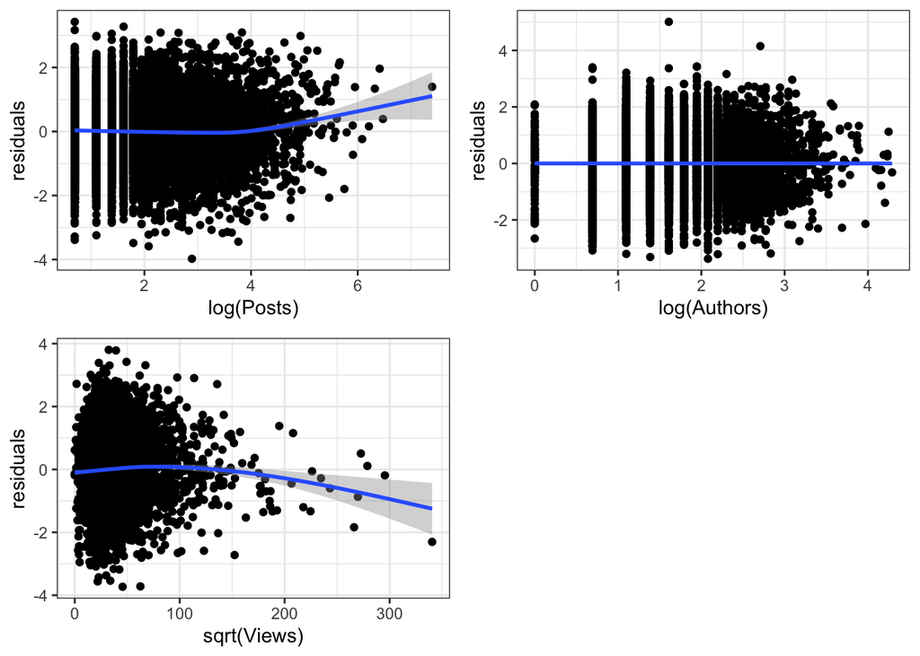

```r
p1 <- sfn %>%
  mutate(residuals = qresid(m1)) %>%
  ggplot(aes(x = log(Posts), y = residuals)) +
  geom_point() +
  geom_smooth() +
  theme_bw()

p2 <- sfn %>%
  mutate(residuals = qresid(m1)) %>%
  ggplot(aes(x = log(Authors), y = residuals)) +
  geom_point() +
  geom_smooth() +
  theme_bw()

p3 <- sfn %>%
  mutate(residuals = qresid(m1)) %>%
  ggplot(aes(x = sqrt(Views), y = residuals)) +
  geom_point() +
  geom_smooth() +
  theme_bw()

grid.arrange(p1, p2, p3, ncol=2)
```

The quantile residual plots look pretty good; I don’t think we need additional transformations on the explanatory variables.

**Grading:** 3 pts for plots (1 pt for each plot), 2 pts for discussing plots. Lose 1 pt if no code shown.

### (f) (1 pt)

I don’t think any further tranformations are needed here.

### (g) (5 pts)

Our null hypothesis is $H_0: \beta_1 = 0$, and our alternative hypothesis is $H_A: \beta_1 \neq 0$. We can conduct a likelihood ratio test by comparing the deviances of the reduced and full models:

```r
m2 <- glm(hasDeleted ~ sqrt(Views) + log(Authors) + Forum,
          family = binomial, data = sfn)
m2$deviance - m1$deviance
```

```
## [1] 140.5621
```

```r
pchisq(m2$deviance - m1$deviance, df=1, lower.tail=F)
```

```
## [1] 2.005825e-32
```

Our drop-in-deviance statistic is $G = 140.56$ and our p-value is approximately 0, so the observed data would be highly unusual if in fact there is no relationship between posts and deleted posts, after accounting for the other variables.

**Grading:** 1 pt for hypotheses, 1 pt for code, 1 pt for test statistic, 1 pt for p-value, 1 pt for conclusion. Lose 1 pt if p-value is interpreted incorrectly (e.g., as the probability that $H_0$ is true)

### (h) (5 pts)

Our null hypothesis is $H_0: \beta_1 = 0$, and our alternative hypothesis is $H_A: \beta_1 \neq 0$. We can conduct a Wald test by calculating a z-statistic:

```r
summary(m1)
```

```
##
## Call:
## glm(formula = hasDeleted ~ log(Posts) + sqrt(Views) + log(Authors) +
##     Forum, family = binomial, data = sfn)
##
## Deviance Residuals:
##     Min       1Q   Median       3Q      Max
## -2.5886  -0.4481  -0.3175  -0.2288   3.5712
##
## Coefficients:
##                   Estimate Std. Error z value Pr(>|z|)
## (Intercept)      -5.208800   0.159628 -32.631  < 2e-16 ***
## log(Posts)       -0.985119   0.087943 -11.202  < 2e-16 ***
## sqrt(Views)       0.011667   0.001647   7.084 1.40e-12 ***
## log(Authors)      2.453371   0.128964  19.024  < 2e-16 ***
## ForumHomework     0.857132   0.176969   4.843 1.28e-06 ***
## ForumMath         0.547780   0.164125   3.338 0.000845 ***
## ForumMedicine     0.594235   0.163337   3.638 0.000275 ***
## ForumMisc         1.051616   0.133020   7.906 2.66e-15 ***
## ForumScience      0.339006   0.111650   3.036 0.002395 **
## ForumSpeculation  0.319083   0.170050   1.876 0.060599 .
## ---
## Signif. codes:  0 '***' 0.001 '**' 0.01 '*' 0.05 '.' 0.1 ' ' 1
##
## (Dispersion parameter for binomial family taken to be 1)
##
##     Null deviance: 6300.6  on 9994  degrees of freedom
## Residual deviance: 5356.2  on 9985  degrees of freedom
## AIC: 5376.2
##
## Number of Fisher Scoring iterations: 6
```

Our z-statistic is $z = -11.2$ and our p-value is approximately 0, so the observed data would be highly unusual if in fact there is no relationship between posts and deleted posts, after accounting for the other variables.

**Grading:** 1 pt for hypotheses, 1 pt for code, 1 pt for test statistic, 1 pt for p-value, 1 pt for conclusion. Lose 1 pt if p-value is interpreted incorrectly (e.g., as the probability that $H_0$ is true)

### (i) (4 pts)

I will construct a 95% interval (though students may choose whichever confidence level they like):

```r
-0.99 + qnorm(0.025, lower.tail=F)*0.088
```

```
## [1] -0.8175232
```

```r
-0.99 - qnorm(0.025, lower.tail=F)*0.088
```

```
## [1] -1.162477
```

Our 95% CI is $(-1.16, -0.82)$. So we are 95% confident that a one-unit increase in log(Posts), holding Views, Authors, and Forum fixed, is associated with a change in the odds that a thread will have a deleted post by a factor of between $e^{-1.16} = 0.31$ and $e^{-0.82} = 0.44$.

**Grading:** 2 pts for interval, 1 pt for interpretation, 1 pt for exponentiating endpoints to interpret in terms of odds.

## Question 4

### (a) (2 pts)

p-values and hypothesis testing are often misunderstood by practitioners, who believe a small p-value provides stronger or more meaningful evidence that it really does. It is also easy to mis-use p-values, for example by continuing to test hypotheses until you get a “small” p-value (e.g., less than 0.05). Finally, p-values don’t provide any other context about the data – whether the effect size is actually meaningful, whether assumptions are satisfied, whether the data are representative of the population, etc.

**Grading:** Answers may vary; students can receive full credit if their answer is somewhat related to some of the ideas described here.

### (b) (2 pts)

One example of mis-interpretation is believing a p-value is the probability that $H_0$ is true. One example of mis-use is p-hacking (continuing to test hypotheses until you get a small p-value).

**Grading:** Answers may vary; students can receive full credit if their answer is reasonable.

### (c) (2 pts)

A p-value is *not* the probability that $H_0$ is true. It also doesn’t provide information about the effect size or about practical significance. And p-values don’t provide other context about whether the model is appropriate for the data.

**Grading:** Answers may vary; students can receive full credit if their answer is reasonable.

### (d) (2 pts)

Report p-values in the context of other findings (effect sizes, confidence intervals, model diagnostics). Don’t rely on a threshold to determine whether a hypothesis is “true” or “false”.

**Grading:** Answers may vary; students can receive full credit if their answer is reasonable.

## Question 5 (Extra Credit)

Students can receive 1 pt of extra credit for each correct answer below, for a maximum of 3 pts of extra credit total.

### (a) (1 pt)

`NA/NaN/Inf in 'x'`

### (b) (1 pt)

Fare can be 0, so when we take log(Fare) we get log(0), which is $-\infty$ in R.

### (c) (1 pt)

Either add a small number to Fare before taking the log (e.g., log(Fare + 1)), or use a different transformation (e.g., square root)